# HW7

Amane Chibana and Harry Wang

2024-04-04

### Q1

```r
Organic = read_excel("./Organic.xls")

OrgGrp = Organic[which(Organic$Food=="Organic"), "Score"]

ConGrp = Organic[which(Organic$Food=="Control"), "Score"]

ComGrp = Organic[which(Organic$Food=="Comfort"), "Score"]

length(OrgGrp$Score);mean(OrgGrp$Score);var(OrgGrp$Score)
```

```
## [1] 20
```

```
## [1] 5.5835
```

```
## [1] 0.3523187
```

```r
length(ConGrp$Score);mean(ConGrp$Score);var(ConGrp$Score)
```

```
## [1] 20
```

```
## [1] 5.0825
```

```
## [1] 0.3864724
```

```r
length(ComGrp$Score);mean(ComGrp$Score);var(ConGrp$Score)
```

```
## [1] 22
```

```
## [1] 4.887273
```

```
## [1] 0.3864724
```

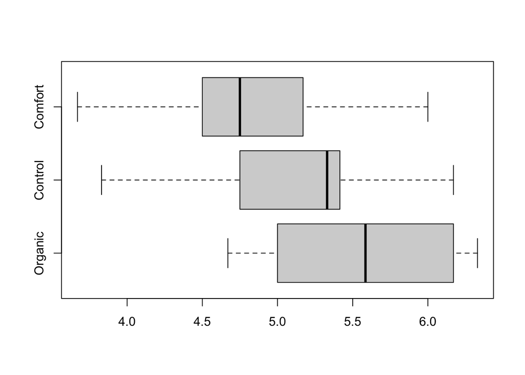

```r
boxplot(c(OrgGrp,ConGrp,ComGrp), horizontal = TRUE,names = c("Organic", "Control","Comfort"))
```

### Q2

```r
var.test(ConGrp$Score,ComGrp$Score, alternative = c("two.sided"),conf.level=0.95)
```

```
##
##  F test to compare two variances
##
## data:  ConGrp$Score and ComGrp$Score
## F = 1.1774, num df = 19, denom df = 21, p-value = 0.7128
## alternative hypothesis: true ratio of variances is not equal to 1
## 95 percent confidence interval:
##  0.4820835 2.9353080
## sample estimates:
## ratio of variances
##           1.177443
```

H0: The population variance of Control and Comfort groups are equal

Ha: The population variance of Control and Comfort groups are not equal

The testing statistic is F = 1.18 with numerator degree of freedom of 19 and denominator degree of freedom of 21. The p-value of this test is 0.71 which is greater than 0.05 which means we fail to reject the null hypothesis and we lack the evidence to say that the variance of the Control and Comfort groups are not equal at significance level α1 = 0.05.

### Q3

```r
t.test(ConGrp$Score,ComGrp$Score, alternative = c("two.sided"),paired = FALSE, var.equal = FALSE, conf.level = 0.99)
```

```
##
##  Welch Two Sample t-test
##
## data:  ConGrp$Score and ComGrp$Score
## t = 1.055, df = 38.76, p-value = 0.298
## alternative hypothesis: true difference in means is not equal to 0
## 99 percent confidence interval:
##  -0.3060280  0.6964825
## sample estimates:
## mean of x mean of y
##  5.082500  4.887273
```

H0: The population means of Control and Comfort groups are equal Ha: The population means of Control and Comfort groups are not equal

The testing statistic is t=1.055 with degree of freedom 38. The p-value of this test is 0.298 which is grater than 0.01 which means we fail to reject the null hypothesis and we lack the evidence to say that the mean of the Control and Comfort groups are not equal at significance level α2 = 0.01.

### Q4

```r
TotalAvg = (sum(OrgGrp$Score)+sum(ConGrp$Score) + sum(ComGrp$Score))/(length(OrgGrp$Score)+length(ConGrp$Score)+length(ComGrp$Score))

data <- data.frame(
  score = c(ConGrp$Score, ComGrp$Score, OrgGrp$Score),
  group = factor(c(rep("Control", length(ConGrp$Score)),
                   rep("Comfort", length(ComGrp$Score)),
                   rep("Organic", length(OrgGrp$Score))))
)

anova_result <- aov(score ~ group, data = data)

OrganicAvg = mean(OrgGrp$Score)
ControlAvg = mean(ConGrp$Score)
ComfortAvg = mean(ComGrp$Score)

OrganicVar = var(OrgGrp$Score)
ControlVar = var(ConGrp$Score)
ComfortVar = var(ComGrp$Score)

SSB = (length(OrgGrp$Score)*(OrganicAvg-TotalAvg)^2)+(length(ConGrp$Score)*(ControlAvg-TotalAvg)^2)+(length(ComGrp$Score)*(ComfortAvg-TotalAvg)^2)
SSE = (length(OrgGrp$Score) - 1)*OrganicVar + (length(ConGrp$Score) - 1)*ControlVar + (length(ComGrp$Score) - 1)*ComfortVar
SST = SSB+SSE

r_squared <- SSB / SST
```

```
## Total Average: 5.174839
```

```
## Organic Average: 5.5835
```

[output not shown]

[output not shown]

```
## Organic Variance: 0.3523187
```

```
## Control Variance: 0.3864724
```

```
## Comfort Variance: 0.3282303
```

```
## SSB: 5.329882
```

```
## SSE 20.92987
```

```
## SST 26.25975
```

```
## ANOVA Results:
```

```
##             Df Sum Sq Mean Sq F value  Pr(>F)
## group        2   5.33  2.6649   7.512 0.00124 **
## Residuals   59  20.93  0.3547
## ---
## Signif. codes:  0 '***' 0.001 '**' 0.01 '*' 0.05 '.' 0.1 ' ' 1
```

```
## R-squared: 0.2029677
```

### Q5

Null Hypothesis (H0): The mean score of the Control group is equal to or less than the average of the Organic and Comfort groups. Alternative Hypothesis (H1): The mean score of the Control group is greater than the average of the Organic and Comfort groups.

```r
mean_organic <- mean(OrgGrp$Score)
mean_control <- mean(ConGrp$Score)
mean_comfort <- mean(ComGrp$Score)

mean_organic_comfort <- (mean_organic + mean_comfort) / 2

contrast <- mean_control - mean_organic_comfort


pooled_sd <- sqrt(((var(OrgGrp$Score) / length(OrgGrp$Score)) + (var(ConGrp$Score) / length(ConGrp$Score)) + (var(ComGrp$Score) / length(ComGrp$Score))) / 3)

se_contrast <- pooled_sd * sqrt((1/length(ConGrp$Score)) + (0.5/length(OrgGrp$Score)) + (0.5/length(ComGrp$Score)))

t_statistic <- contrast / se_contrast

df <- (se_contrast^4) / (((var(OrgGrp$Score) / length(OrgGrp$Score))^2 / (length(OrgGrp$Score) - 1)) + ((var(ConGrp$Score) / length(ConGrp$Score))^2 / (length(ConGrp$Score) - 1)) + ((var(ComGrp$Score) / length(ComGrp$Score))^2 / (length(ComGrp$Score) - 1)))

p_value <- pt(-abs(t_statistic), df)
```

```
## Contrast:  -0.1528864
```

```
## T-statistic:  -3.719709
```

```
## Degrees of Freedom:  0.06126212
```

```
## P-value:  0.4064803
```

There is not sufficient evidence at the significance level 0.1 to conclude that the Control group’s mean score is higher than the average of the Organic and Comfort groups. In fact, the data suggests the opposite.

### Q6

```r
library(agricolae)

group <- c(rep('Organic', 20), rep('Control', 20), rep('Comfort', 22))
score <- c(4.83, 5.50, 6.33, 6.33, 5.67, 6.17, 5.50, 5.00, 5.00, 6.33, 6.17, 4.83, 4.67, 5.50, 5.83, 4.67, 6.17, 5.33, 6.17, 5.67,
           5.33, 5.67, 5.33, 5.17, 5.67, 5.67, 3.83, 5.33, 4.67, 4.83, 5.33, 3.83, 5.33, 5.33, 4.33, 5.50, 5.17, 6.17, 4.83, 4.33,
           5.83, 5.00, 6.00, 5.00, 4.17, 4.67, 5.17, 5.50, 4.67, 4.50, 5.17, 5.17, 4.50, 4.67, 4.83, 5.83, 5.17, 4.33, 4.67, 4.33, 4.67, 3.67)

data <- data.frame(group, score)

model <- aov(score ~ group, data = data)
lsd_test <- LSD.test(model, "group", p.adj = "none")

lsd_test
```

```
## $statistics
##     MSerror Df     Mean      CV
##   0.3547435 59 5.174839 11.5096
##
## $parameters
##         test p.ajusted name.t ntr alpha
##   Fisher-LSD      none  group   3  0.05
##
## $means
##            score       std  r        se      LCL      UCL  Min  Max    Q25
## Comfort 4.887273 0.5729139 22 0.1269831 4.633180 5.141365 3.67 6.00 4.5425
## Control 5.082500 0.6216690 20 0.1331810 4.816005 5.348995 3.83 6.17 4.7900
## Organic 5.583500 0.5935644 20 0.1331810 5.317005 5.849995 4.67 6.33 5.0000
##           Q50    Q75
## Comfort 4.750 5.1700
## Control 5.330 5.3725
## Organic 5.585 6.1700
##
## $comparison
## NULL
##
## $groups
##            score groups
## Organic 5.583500      a
## Control 5.082500      b
## Comfort 4.887273      b
##
## attr(,"class")
## [1] "group"
```